# Sankey plots with R

On this page I explore different R packages for building sankey plots to be integrated in an interactive Shiny app.

The idea of this app is that the user will be able to upload their own dataset to the Shiny app, select the data columns that should be used for plotting, customise the plot as desired, and finally download a static image (png/jpg) of the plot.

After some research and playing around with different options I decided to narrow it down to the ggalluvial and ggforce packages.

## Which package?

The other packages in the running were alluvial, googleVis, riverplot, and networkD3. I disregarded each of these for one or multiple of the following reasons:

- the data structures needed didn’t seem suitable for easy reformatting of different data types
- I wasn’t happy with the aesthetics of the plots
- the plot couldn’t be exported as a png/jpg with the shiny downloadHandler
- the plotting functionality wasn’t compatible with the ggplot2 package to extend on the styling.

To identify which of `ggalluvial` and `ggforce` is better suited for the task I used two datasets to create plots that make use of the functionality and plotting features of the two packages in different ways. From the first dataset we will create sankey plots visualising the flows between two “axes” only, from the second one we will create one with flows between three axes.

This makes it easier to identify which package is preferable with respect to being able to deliver on various different desired outcomes the user might have based on the nature of the data, and we can identify the format in which the data needs to be and whether the raw data can straightforwardly be reformated to that format based on the user input.

First of all, we load in the required packages.

```r
library("dplyr")
library("tidyr")
library("ggplot2")
library("ggforce")
library("ggalluvial")
library("ggfittext")
```

## Some thoughts on the data format

We start by reformatting the data so that it can be used by the two packages. In fact, both packages need the data to be formatted in the same way, if we use the **‘long’** format in the `ggalluvial` package. The `ggalluvial` accepts two different data formats, a ‘wide’ and a ‘long’ format. For the ‘wide’ format, which is slightly more intuitive to understand as it’s basically just a frequency table of each “cohort”, one needs to specify each axis separately in the aesthetics (aes) of ggplot (`aes(y=frey, axis1= .., axis2= .., axis3=..)`) which makes it harder to automate this for a flexible user input. We therefore use the ‘long’ format which means we can easily use the data for both `ggalluvial` and `ggforce` plots and compare them based on other functionalities, such as plotting options, aesthetics, etc.

To prepare the data to work with the alluvial plots, it first needs to be converted to a format of one row per “cohort” of observations, with a final frequency column that specifies the number of observations in the cohort. This is assuming the input data will be in the “raw” format of one row per observation.

The user first chooses the column names from the raw data that will be the “axes” along the x-axis between which the flows will be plotted. The user can then (optionally) also choose a fill variable to choose the colouring of the flows, as well as an ordering of the strata. This will be shown further down in this document.

## Example 1: Vote choice in the 2017 and 2019 UK general elections

For the traditional sankey plot between only two ‘axes’ I used polling data from the [British Election Study](https://www.britishelectionstudy.com/) about vote choice of electors in the 2017 and 2019 general elections in the UK.

In this example, the original data consists of one row per voter, with one column for their vote choice in 2017 (vote17) and one for their vote choice in 2019 (vote19). The two “axes” between we want to display the flows are “vote17” and “vote19”, so we need to group the original dataframe by those two columns to calculate the frequency for each “cohort”. The user input would therefore specify these two columns. We will see a bit later on an example in which the flows should be coloured by the 2017 vote choice. For this the user can (optionally) specify the `fill_input`.

```r
cols_input <- c("vote17", "vote19")
fill_input <- "vote17" # optional
if(is.null(fill_input) | fill_input %in% cols_input){
  groupby <- cols_input
} else {
  groupby <- c(cols_input, fill_input)
}
```

### Data formatting

From the raw data the format can easily be converted to the frequency table by using dplyr’s `group_by_at` functionality, using the string vector `groupby` as the grouping variables. We will see later on why we’re creating an extra `groupby` parameter from `cols_input`.

In this case, the data was already grouped before. It would then, after grouping, look as follows:

```r
dat_17_19 <- read.csv("sankey_data.csv")
head(dat_17_19)
```

```
##           vote17             vote19 freq
## 1 Conservative17     Brexit Party19   57
## 2 Conservative17     Conservative19 2083
## 3 Conservative17      Green Party19   19
## 4 Conservative17           Labour19   70
## 5 Conservative17 Liberal Democrat19  123
## 6  Green Party17     Brexit Party19    1
```

To achieve the desired format for the sankey plots, we first add an `id` column, that gives a unique ID to each cohort. As one row in the frequency table represents one cohort, we can use row numbers to create this ID.

We then use tidyr’s `gather` function with the `cols_input` to select the columns to be gathered, to convert the data to the format needed for `ggforce` and `ggalluvial`:

```r
dat <- dat_17_19 %>%
  mutate(id = row_number())

dat_plot <- dat %>%
  tidyr::gather(key = "x",
                value = "stratum",
                cols_input)

head(dat_plot)
```

```
##   freq id      x        stratum
## 1   57  1 vote17 Conservative17
## 2 2083  2 vote17 Conservative17
## 3   19  3 vote17 Conservative17
## 4   70  4 vote17 Conservative17
## 5  123  5 vote17 Conservative17
## 6    1  6 vote17  Green Party17
```

In this format, the data now has one row **for each stratum**. In this example, this means that there are two rows for each cohort (`id`), one showing the 2017 vote choice and one showing the 2019 vote choice. We can see this if we sort by the `id` column:

```r
head(dat_plot %>% arrange(id))
```

```
##   freq id      x        stratum
## 1   57  1 vote17 Conservative17
## 2   57  1 vote19 Brexit Party19
## 3 2083  2 vote17 Conservative17
## 4 2083  2 vote19 Conservative19
## 5   19  3 vote17 Conservative17
## 6   19  3 vote19  Green Party19
```

### Plotting functions

The plot functions uses the `dat_plot` dataframe and the relevant columns. For these first two sankey plots, I’ve given the functions that create the stata and flows only the necessary parameters to create very basic plots. Further down we will see how we can change more parameters to customise the look of the plots.

The code and output looks as follows:

#### ggalluvial

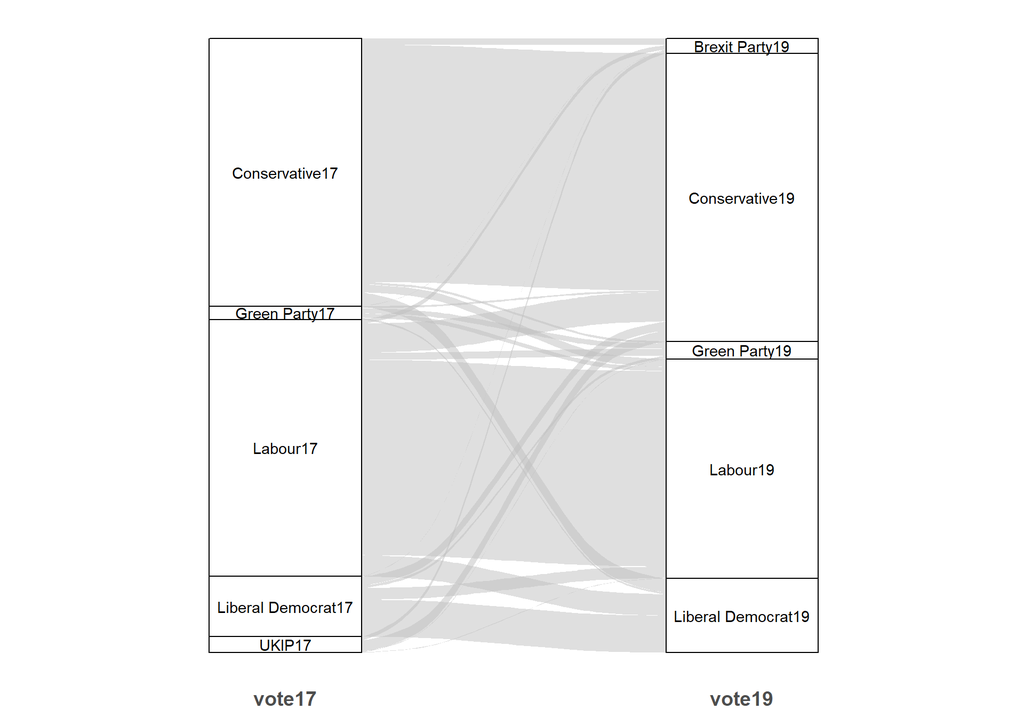

```r
  ggplot(dat_plot,
       aes(x = x,
           stratum = stratum,
           alluvium = id,
           y = freq,
           label = stratum)) +
  geom_lode() +
  geom_flow() +
  geom_stratum() +
  geom_text(stat = "stratum", label.strata = TRUE) +
  theme_minimal() +
  theme(
    panel.grid.major = element_blank(),
    panel.grid.minor = element_blank(),
    axis.text.y = element_blank(),
    axis.text.x = element_text(size = 14, face = "bold"),
    axis.title  = element_blank()
  )
```

#### ggforce

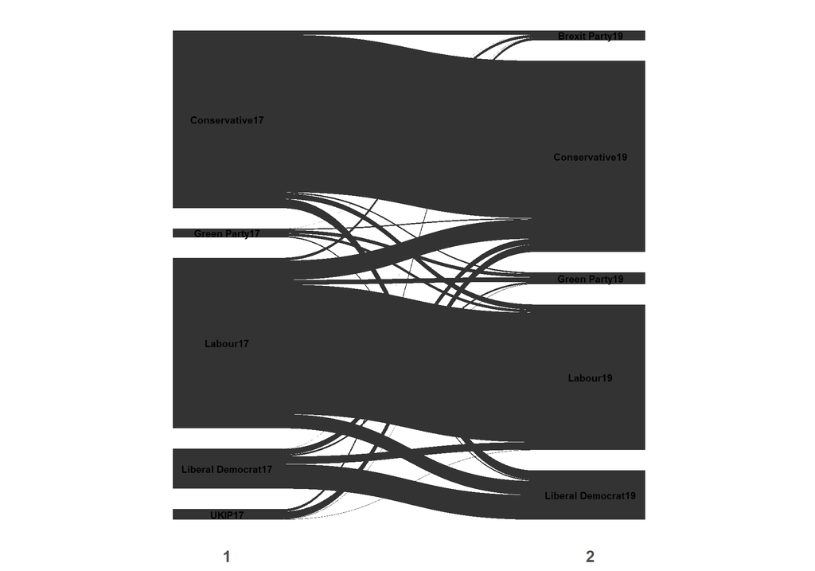

```r
ggplot(dat_plot, aes(x = x, id = id, split = stratum, value = freq)) +
  geom_parallel_sets(axis.width = 0.3,
                     n=1000) +
  geom_parallel_sets_axes(axis.width = 0.3,
                          size = 0.3) +
  geom_parallel_sets_labels(size = 3,
                            angle = 0,
                            fontface="bold") +
  scale_x_discrete(labels = labels) +
  theme_minimal() +
  theme(
    panel.grid.major = element_blank(),
    panel.grid.minor = element_blank(),
    axis.text.y = element_blank(),
    axis.text.x = element_text(size = 14, face = "bold"),
    axis.title  = element_blank()
  )
```

### Change order of strata and colours

Now, what if we want the flows to be shown in a certain order? And if we want the flows to be coloured depending on a certain variable in the data? We also might want to change the width, border and fill colour of the strata!

Note that for the colouring part of this, the fill variable needs to be part of the frequency table that we create from the raw data by grouping it. In this case, the fill variable is one of the two columns that were used to create the frequency table anyway. However, as we will see in the example below, that doesn’t need to be the case. When it is an additional variable that the flow colours are filled by, the `group_by_at` function we use to group the raw data needs to conditionally include the extra fill variable when it was specified by the user.

Before we prepare the data for this case, we show the parameters specified for the ordering of the strata and the colour vector.

In this case, the user has chosen that the vote17 axis should be ordered as specified by `fct_levels17` and the vote19 axis is ordered by `fct_levels19`. In order for the ordering to work, we then need to create one combined level vector from those two vectors (denoted `fct_levels_all` in the code below).

Note that this could be an issue if the user only chooses the order of one of the axes. In that case we need to specify that the code uses the automatic (alphabetical) ordering of the levels of the other axis (or axes if there are more than two overall) if no ordering is specified.

```r
###=================================================================================
### define factor levels to specify order of strata
fct_levels <- c("Labour", "Conservative", "Liberal Democrat", "UKIP",
                "Brexit Party", "Green Party", "SNP", "Plaid Cymru")
fct_levels17 <- paste0(fct_levels, "17")
fct_levels19 <- paste0(fct_levels, "19")
fct_levels_all <- c(fct_levels17, fct_levels19)
fct_levels_all
```

```
##  [1] "Labour17"           "Conservative17"     "Liberal Democrat17"
##  [4] "UKIP17"             "Brexit Party17"     "Green Party17"
##  [7] "SNP17"              "Plaid Cymru17"      "Labour19"
## [10] "Conservative19"     "Liberal Democrat19" "UKIP19"
## [13] "Brexit Party19"     "Green Party19"      "SNP19"
## [16] "Plaid Cymru19"
```

For our plots, we want the flows to be coloured by the official colours of the political parties according to the 2017 vote choice. The colour vector needs to have one colour for each level of that variable and is then named according to the factor levels of the specified column. In the code for the app, this will look differently, as the user should be able to directly choose a colour for each level, *or* choose a colour palette if preferred. This part here is to show what the colour vector needs to look like for plotting.

```r
###=================================================================================
### define plot colours
colours <- c("#DC241f", "#0087DC", "#FAA61A", "#70147A",
            "#12B6CF", "#528D6B", "#FDF38E", "#008142")
names(colours) <- fct_levels17
colours
```

```
##           Labour17     Conservative17 Liberal Democrat17             UKIP17
##          "#DC241f"          "#0087DC"          "#FAA61A"          "#70147A"
##     Brexit Party17      Green Party17              SNP17      Plaid Cymru17
##          "#12B6CF"          "#528D6B"          "#FDF38E"          "#008142"
```

### Data formatting (with ordering and colours)

To reflect these optional user input parameters, the data formatting needs to have two extra steps. These will be conditional to the user having specified any of the optional parameters.

The `left_join` in the following `dplyr` pipe ensures that the necessary fill variable is included in the data frame. The `mutate_at` ensures that the strata are displayed in the order that was defined by the user. Again, this will only be necessary if the user has specified an order.

```r
### format data
dat <- dat_17_19 %>%
  mutate(id = row_number())

dat_plot <- dat %>%
  tidyr::gather(key = "x",
                value = "stratum",
                factor_key = TRUE,
                cols_input) %>%
  left_join(dat %>%
              mutate_(fill = fill_input) %>%
              select(id, fill),
            by = "id") %>%
  mutate_at(vars(stratum),
            funs(factor(., levels = fct_levels_all)))

head(dat_plot)
```

```
##   freq id      x        stratum           fill
## 1   57  1 vote17 Conservative17 Conservative17
## 2 2083  2 vote17 Conservative17 Conservative17
## 3   19  3 vote17 Conservative17 Conservative17
## 4   70  4 vote17 Conservative17 Conservative17
## 5  123  5 vote17 Conservative17 Conservative17
## 6    1  6 vote17  Green Party17  Green Party17
```

### Prepare Plot styling options

Now that we have the data in the right format, we can specify some styling parameters for the plots. Some or all of these could be specified by the user (especially the labels). There are more options for making it possible for the user to change any of the standard `ggplot` settings (font type, size, text, etc of the labels, titles and so on).

```r
stratum_width <- 0.2
stratum_font_colour <- "black"
stratum_fill_colour <- "white"
stratum_line_colour <- "black"
stratum_angle <- 0
legend_position <- ""
alpha <- 0.7
labels <- c("GE vote 2017", "GE vote 2019")
```

### Plotting functions (with ordering and colours)

We can see that with these extra parameters, the flows are now ordered according to the defined factor levels and coloured by the 2017 vote choices.

#### ggalluvial

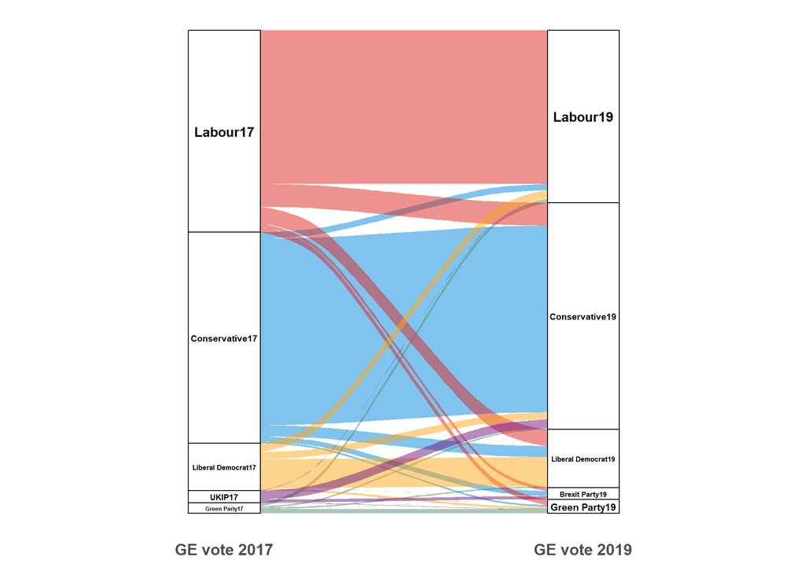

```r
  ggplot(dat_plot,
       aes(x = x, stratum = stratum, alluvium = id,
           y = freq, label = stratum, fill = fill)) +
  geom_lode(width = stratum_width) +
  geom_flow(width = stratum_width) +
  geom_stratum(width = stratum_width,
               fill = stratum_fill_colour,
               colour = stratum_line_colour) +
  ggfittext::geom_fit_text(stat = "stratum",
                           width = stratum_width,
                           colour = stratum_font_colour,
                           fontface = "bold",
                           min.size = 3) +
  scale_fill_manual(values = colours) +
  scale_color_manual(values = colours) +
  scale_x_discrete(labels = labels) +
  theme_minimal() +
  theme(
    legend.position = legend_position,
    panel.grid.major = element_blank(),
    panel.grid.minor = element_blank(),
    axis.text.y = element_blank(),
    axis.text.x = element_text(size = 14, face = "bold"),
    axis.title  = element_blank()
  )
```

#### ggforce

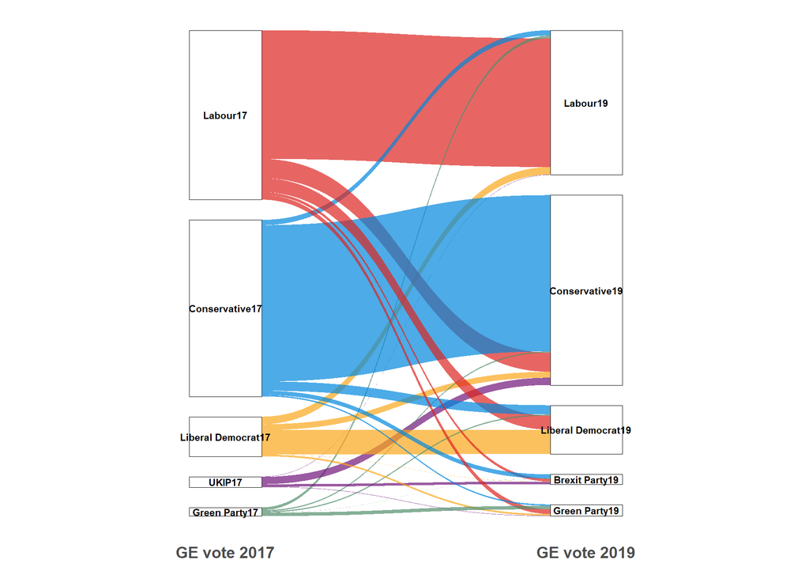

```r
ggplot(dat_plot, aes(x = x, id = id, split = stratum, value = freq)) +
  geom_parallel_sets(aes(fill = fill),
                     alpha = alpha,
                     axis.width = stratum_width,
                     n=1000) +
  geom_parallel_sets_axes(axis.width = stratum_width,
                          fill = stratum_fill_colour,
                          color = stratum_line_colour,
                          size = 0.3) +
  geom_parallel_sets_labels(colour = stratum_font_colour,
                            size = 3,
                            angle = stratum_angle,
                            fontface="bold") +
  scale_fill_manual(values  = colours) +
  scale_color_manual(values = colours) +
  scale_x_discrete(labels = labels) +
  theme_minimal() +
  theme(
    legend.position = legend_position,
    panel.grid.major = element_blank(),
    panel.grid.minor = element_blank(),
    axis.text.y = element_blank(),
    axis.text.x = element_text(size = 14, face = "bold"),
    axis.title  = element_blank()
  )
```

### Pros and cons

We can see that we can easily pass the dataframe and styling parameters to both `ggforce` and `ggalluvial` and create sankey plots that display the desired information pretty clearly.

Just to see the effect, we used a rather small `stratum_width` parameter and we can see that in both cases this did in fact change the width of the strata. One advantage of `ggalluvial` is that it works with the `geom_fit_text` function from `ggfittext` so that; this automatically fits the text of the stratum labels to the stratum width. This functionality doesn’t work with `ggforce` and I haven’t found an alternative, so that the labels overlab the stratum width.

Other than that, the parameters that can be adapted in the plots from `ggforce` and `ggalluvium` are very similar - in both we can set colours and orders of flows, as well as fill and border colours and font style of the strata.

So far I can see an argument for letting the user choose between the two different types of sankey plots. Both are easily adaptable and it might be a case of choosing the one for which the aesthetics work better with the type of data the user is working with. Let’s look at an example with three axes.

## Example 2: Titanic

For the case of more than two axes I used the famous titanic dataset that is built into R. Obviously the data here doesn’t represent change over time but represents multiple (in this case demographical) dimensions on a 2D plot by showing the frequencies as flows between them. Let’s say the three “axes” we are interested in are ‘Class’, ‘Sex’, and ‘Age’ - this will be the user input, reflected by `cols_input`.

Because the outcome variable in the titanic dataset is whether or not a person survived the crash, this variable is visualised as an ‘extra’ dimension additional to the axes in the sankey plot, namely a distinction by colour. This can be defined by the user and is reflected here by the `fill_input` parameter.

```r
cols_input <- c("Class", "Sex", "Age")
fill_input <- "Survived"
if(is.null(fill_input) | fill_input %in% cols_input){
  groupby <- cols_input
} else {
  groupby <- c(cols_input, fill_input)
}
```

### Data formatting

The example Titanic data also already comes in the frequency table format. If this was the raw data (i.e. one row for each passenger with their demographic variables and whether or not they survived the crash) we would again use dplyr’s `group_by_at` functionality. This time, the `groupby` parameter consists of both `cols_input` and `fill_input`; this is necessary so that the fill parameter can be used to colour the flows in the plots.

To format the data further we again add an `id` column and then use tidyr’s `gather` function with the `cols_input` to select the columns to be gathered.

```r
dat <- Titanic %>%
  as.data.frame() %>%
  mutate(id = row_number())
head(dat)
```

```
##   Class    Sex   Age Survived Freq id
## 1   1st   Male Child       No    0  1
## 2   2nd   Male Child       No    0  2
## 3   3rd   Male Child       No   35  3
## 4  Crew   Male Child       No    0  4
## 5   1st Female Child       No    0  5
## 6   2nd Female Child       No    0  6
```

```r
dat_plot <- dat %>%
  tidyr::gather(key = "x",
                value = "stratum",
                factor_key = TRUE,
                cols_input) %>%
  left_join(dat %>%
              mutate_(fill = fill_input) %>%
              select(id, fill),
            by = "id")

head(dat_plot)
```

```
##   Survived Freq id     x stratum fill
## 1       No    0  1 Class     1st   No
## 2       No    0  2 Class     2nd   No
## 3       No   35  3 Class     3rd   No
## 4       No    0  4 Class    Crew   No
## 5       No    0  5 Class     1st   No
## 6       No    0  6 Class     2nd   No
```

Again, there is now one row **for each stratum**. In the titanic example, this means that there are now **three** rows for each cohort (`id`), one for each axis (Class, Sex, and Age). Let’s visualise this again by sorting by `id`.

We can see that `dat_plot` again has the necessary `fill` column. The difference being that in this case the fill variable is not one of the axes in the plot, but an extra dimension.

```r
head(dat_plot %>% arrange(id))
```

```
##   Survived Freq id     x stratum fill
## 1       No    0  1 Class     1st   No
## 2       No    0  1   Sex    Male   No
## 3       No    0  1   Age   Child   No
## 4       No    0  2 Class     2nd   No
## 5       No    0  2   Sex    Male   No
## 6       No    0  2   Age   Child   No
```

### Prepare Plot styling options

We plot some style options again, this time we change the colours of the strata to be black, with white font, and we just choose the colours to be orange and blue.

```r
stratum_width = 0.4
stratum_font_colour = "white"
stratum_fill_colour = "black"
stratum_line_colour = "white"
stratum_angle = 0
legend_position = "right"
alpha <- 0.7
flow_colours <- c("orange", "blue")
```

### Plotting functions

The plots with these parameters look as follows:

### ggalluvial

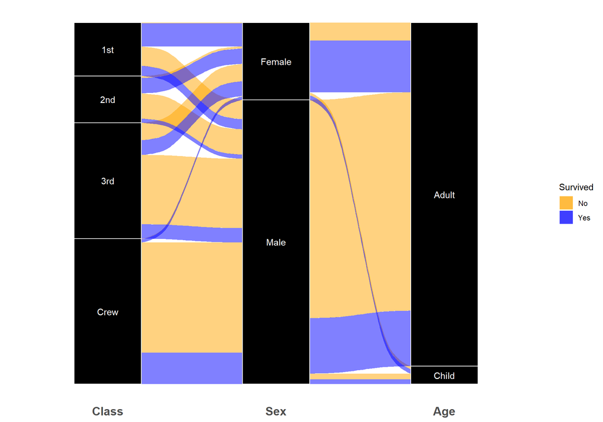

```r
ggplot(dat_plot,
       aes(x = x, stratum = stratum, alluvium = id,
           y = Freq, label = stratum, fill = fill)) +
  geom_lode(width = stratum_width) +
  geom_flow(width = stratum_width) +
  geom_stratum(width = stratum_width,
               alpha = 1,
               fill = stratum_fill_colour,
               colour = stratum_line_colour) +
  geom_text(stat = "stratum", colour = stratum_font_colour) +
  scale_fill_manual(name = fill_input, values  = flow_colours) +
  scale_color_manual(values = flow_colours) +
  theme_minimal() +
  theme(
    legend.position = legend_position,
    panel.grid.major = element_blank(),
    panel.grid.minor = element_blank(),
    axis.title.y = element_blank(),
    axis.title.x = element_blank(),
    axis.text.y = element_blank(),
    axis.text.x = element_text(size = 14, face = "bold")
  )
```

### ggforce

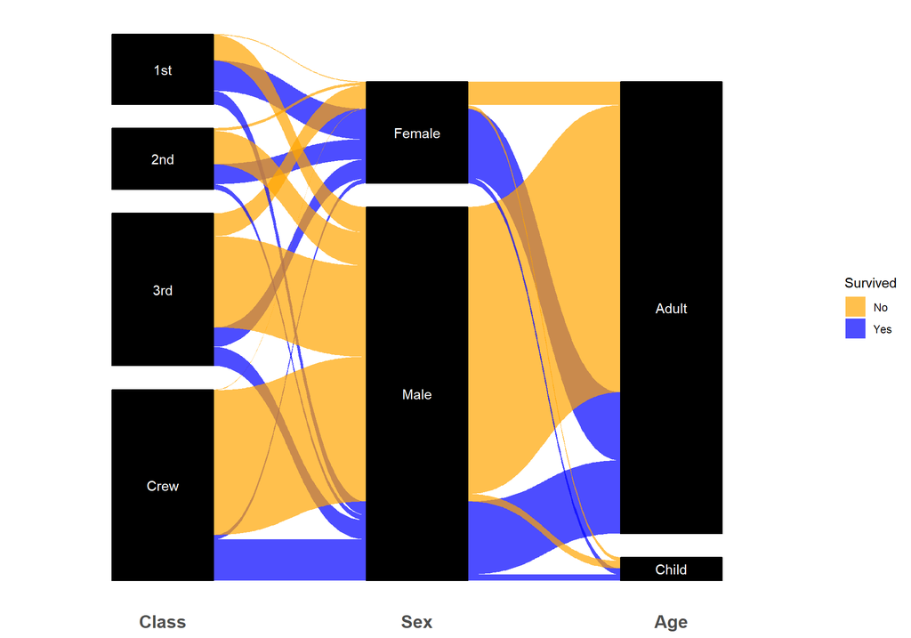

```r
ggplot(dat_plot, aes(x = x, id = id, split = stratum, value = Freq)) +
  geom_parallel_sets(aes(fill = fill), alpha = alpha, axis.width = stratum_width) +
  geom_parallel_sets_axes(axis.width = stratum_width,
                          fill = stratum_fill_colour,
                          colour = stratum_fill_colour) +
  geom_parallel_sets_labels(colour = stratum_font_colour, angle = stratum_angle) +
    scale_fill_manual(name = fill_input, values  = flow_colours) +
  scale_color_manual(values = flow_colours) +
  theme_minimal() +
  theme(
    legend.position = legend_position,
    panel.grid.major = element_blank(),
    panel.grid.minor = element_blank(),
    axis.text.y = element_blank(),
    axis.text.x = element_text(size = 14, face = "bold"),
    axis.title.x  = element_blank()
  )
```

### Pros and cons

Again we see that even with more than just two axes the data for both package is easily prepared and they can be passed parameters to change the aesthetics. Even adding an extra dimension as the fill colour works well in both cases.

With only two different colours the readability of the `ggalluvial` plot is considerably improved. The fact that there is no white space between the stratum actually has the advantage that it causes all three axes to be the same height; it would be nice if there was an option to equalise the height of the axes in `ggforce` (so far I haven’t found a way to do so).

However, I still think overall that the separation of the strata in `ggforce` means the readability of `ggforce` is slightly ahead of that of `ggalluvial`.

## Summary

After playing around with the two packages for a while and having tried to get them to display very similar results for the different datasets my conclusion is that while they’re both reasonable options for the desired outcome, I have a slight preference for the `ggforce` package. But I do think it may be sensible to include a toggle in the app with which the user can switch between the two plots, and eventually download the preferred of the two options.

In general, it’s worth adding that there are few things that I’m missing in both packages, for which I might need to do some more research.

- For both packages, I haven’t found a way to easily adjust the overall shape of the plot, in particular the distance between the axes. It would be nice to have more flexibility (and definitely easier handling) with respect to the length and width but so far I haven’t been able to do that.
- For the two-axes example, it would be nice to be able to have the option to split the colour of the strata separately for each axis and then set a colour gradient between the strata for those flows that don’t have the same source and target (for example a red-blue gradient for those voters that changed from Labour to Conservative).

It’s possible that options exist to achieve these things - some more research is definitely required. Building my own extensions to achieve some of these additional features is also a potential at some point further down the line.